# Algoritmo EM em Modelos de Misturas

Autor

Milena Paz Freitas

# 1. Formulação do Modelo como Estrutura de Dados Incompletos

Como descrito por McLachlan; Krishnan (2008), a mistura (univariada) com $n$ dados observados $\bm y=(y_1,...,y_n)$ pode ser formulada pela composição com uma variável $\bm Z$ latente que indique a qual “grupo” cada observação pertence, de forma que os dados completos sejam $\bm{y_c}= (\bm y^\intercal,\bm z^\intercal)$. Essa formulação se inspira em um método de geração de misturas que, de acordo com Basso; Dávila (2010), considera uma variável aleatória $\bm Z_i$ categórica e $g$-dimensional pela qual a densidade de $Y_i$ é condicionada:

$$Z_{ij}=
\begin{cases}
1\text{, se } Y_i\text{ pertence ao grupo } j
\\
0\text{, c.c.}
\end{cases};\quad j=1,...,g.\quad i=1,...,n.$$
Ou seja, $\bm Z_i$ é multinomial com pesos $\bm p=(p_1,...,p_g)$ e tamanho $n=1$. Logo, sua função de probabilidades (marginal) é dada por: $\text{ }p(\bm z_i)= \prod^g_{j=1} p_j^{z_{ij}}$. Assim, podemos dizer que a função densidade de probabilidade de $Y_i$ condicionada por $\bm Z_i$ é:

$$f(y_i|\bm\theta,\bm z_i)= \prod^g_{j=1}p_j^{z_{ij}}f_j(y_i|\bm \theta_j)^{z_{ij}},$$

onde $\theta_j$ são os parâmetros de $y_i$ correspondentes ao grupo $j$ e $f_j$ as densidades componentes da mistura. A função de verossimilhança completa, considerando $Y_i$ independentes e identicamente distribuidos, seria:

$$L_c(\bm p, \bm \theta)=\prod^n_{i=1}\prod^g_{j=1}\left[p_jf_j(y_i|\bm \theta_j)\right]^{z_{ij}}$$

Logo:

$$l_c(\bm p,\bm\theta)= \sum^g_{j=1}\sum^n_{i=1}z_{ij}\left[\log p_j+\log f_j(y_i|\bm \theta_j)\right]$$

é a log-verossimilhança completa.

# 2. Algoritmo EM em Modelos de Misturas

Usando a estrutura acima, podemos aplicar o algoritmo EM ou alguma extensão do mesmo. Digamos que $\bm \Psi=(\bm p,\bm \theta)$ , a função esperança da log-verossimilhança completa condicionada em $\bm y$ é como segue:

$$\begin{aligned}
Q(\bm \Psi|\bm{\Psi\k{k}})&=\text E [l_c(\bm \Psi)|\bm y, \bm \Psi\k{k}]
\\
&=\sum^g_{j=1}\sum^n_{i=1}\text{E}[z_{ij}|\bm y,\bm \Psi\k{k}]\left(\log p_j\k{k}+\log f_j(y_i|\bm \theta_j\k{k})\right)
\\
&=\sum^g_{j=1}\sum^n_{i=1}\hat{z}_{ij}\left(\log p_j\k{k}+\log f_j(y_i|\bm \theta_j\k{k})\right)
\end{aligned}$$

Onde $\hat z_{ij}$ é a probabilidade *a posteriori* do $i$-ésimo valor observado ($y_i$) fazer parte do $j$-ésimo grupo, ou seja:

$$\hat z_{ij}= \text{P}(Z_{ij}=1|\bm y,\bm \Psi) =
\frac{p_{j}\k{k} f_j(y_i|\bm \theta_j\k{k})}{\sum^g_{h=1} p_h\k{k} f_h(y_i|\bm \theta_h\k{k})}$$

Considerando apenas os pesos $\bm p$ como desconhecidos, a etapa E seria encontrar esse $\hat z_{ij}$, enquanto a etapa M consistiria em obter $\hat{\bm{p}}\k{k+1}$. Como obtido anteriormente, o estimador de máxima verossimilhança para $\bm{p}$ é $\hat{ \bm{p}}=\left(\frac{\sum^n_{i=1}z_{i1}}{n},...,\frac{\sum^n_{i=1}z_{ig}}{n}\right)$. Logo, temos para o passo M:

$$\hat{ \bm{p}}\k{k+1}= \left(\sum^n_{i=1}\hat{z}_{i1}/n,...,\sum^n_{i=1}\hat z_{ig}/n\right)$$

## 2.1 Exemplo: Mistura Normal com Duas Componentes (médias e variâncias conhecidas)

Vamos gerar uma mistura gaussiana no R e usar o algoritmo EM para estimar os pesos. Usando o método de geração pela multinomial para uma mistura $0.64\mathcal{N}(160, 15) + 0.36\mathcal{N}(173, 12)$, temos os seguintes dados:

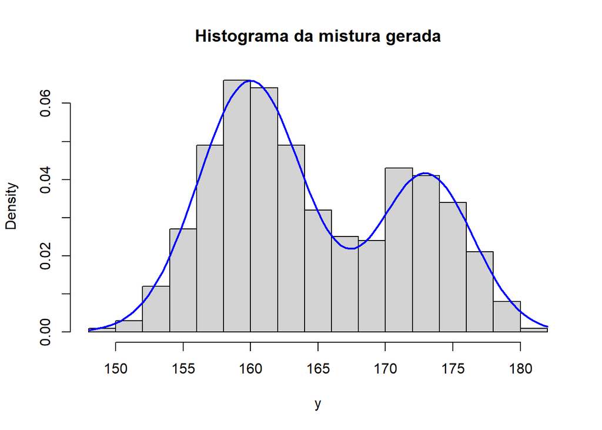

```r
#Fixando os parâmetros
P <- c(0.64,0.36)
mu <- c(160,173)
sigma <- sqrt(c(15,12))
n<- 500

grupos <- t(rmultinom(n, 1, prob=P))
y <- numeric(n)
for(i in 1:2)
  y[as.logical(grupos[,i])] <- rnorm(sum(grupos[,i]), mu[i],sigma[i])


hist(y,freq=F,breaks=20, main="Histograma da mistura gerada")
curve(P[1]*dnorm(x,mu[1],sigma[1]) + P[2]*dnorm(x,mu[2],sigma[2]),add=T,col="blue",lwd=2)
```

#### Simulação

Agora, implementando o algoritmo EM como foi enunciado na Seção 2, temos:

```r
l <- function(p){
  sum(log(p[1]*dnorm(y,mu[1],sigma[1])+p[2]*dnorm(y,mu[2],sigma[2])))
}

crit <- function(ll,p){
  ll2 <- l(p)
  abs(ll2-ll)/(abs(ll) + 1e-8) > 1e-7
}

component <- function(x,g){
  dnorm(x,mu[g],sigma[g])
}

EM <- function(p){
  cont<-1
  l1<-100
  z <- 1
  while(crit(l1,p)){
    #--------PASSO E--------#
    z <- sapply(y,function(y){
      sapply(1:2,function(j) p[j]*component(y,j)/sum(p[1]*component(y,1),p[2]*component(y,2)))
    })
    #-----------------------#
    l1<- l(p)
    #--------PASSO M--------#
    p <- apply(z,1,mean)
    #-----------------------#
    cat("Iteração ",cont,": phat=",p,"\n")
    cont<-cont+1
  }
  return(p)
}

#chute inicial de equiprobabilidade
EM(c(0.5,0.5))
```

```
Iteração  1 : phat= 0.6255043 0.3744957
Iteração  2 : phat= 0.6397275 0.3602725
Iteração  3 : phat= 0.6413922 0.3586078
Iteração  4 : phat= 0.6415886 0.3584114
```

```
[1] 0.6415886 0.3584114
```

## 2.2. Exemplo: Mistura Normal com Duas Componentes (médias e variâncias desconhecidas)

Suponhamos que seja a mesma mistura em 2.1, mas dessa vez não se sabe os parâmetros das componentes (apenas o número de componentes). O passo E segue idêntico, mas agora o passo M envolve encontrar os estimadores de máxima verossimilhança de $\mu_1, \mu_2$ e $\sigma^2_1,\sigma^2_2$:

$$l_c(\bm \Psi)=
\sum^g_{j=1}\sum^n_{i=1}z_{ij}\left\{\log p_j-\frac{1}{2}\left[\log\sigma^2_j-\frac{(y_i-\mu_j)^2}{\sigma^2_j}\right]+c\right\},$$

onde $c$ é uma constante em relação a $\bm \Psi=(\bm p,\bm \mu,\bm \sigma)$. Logo, temos que:

$$\begin{aligned}
Q(\bm \Psi|\bm{\Psi\k{k}})&=\text E [l_c(\bm \Psi)|\bm y, \bm \Psi\k{k}]
\\
&=\sum^g_{j=1}\sum^n_{i=1}\hat z_{ij}\left\{\log p_j-\frac{1}{2}\left[\log\sigma^2_j+\frac{(y_i-\mu_j)^2}{\sigma^2_j}\right]+c\right\}
\end{aligned}$$

Logo, para o passo M:

$$\frac{dQ(\bm \Psi|\bm{\Psi\k{k}})}{d\mu_j}=\sum^n_{i=1}\hat z_{ij}\frac{(y_i-\mu_j)}{\sigma^2_j}$$

$$\Rightarrow \frac{\sum^n_{i=1}z_{ij}\k{k}(y_i-\mu_j\k{k+1})}{{\sigma^2_j}\k{k}}=0
\Rightarrow \sum^n_{i=1}\hat z_{ij}\k{k}y_i=\sum^n_{i=1}\hat z_{ij}\k{k}\mu_j\k{k+1}$$

$$\Rightarrow
\mu_j\k{k+1}=\frac{\sum^n_{i=1}\hat z_{ij}\k{k}y_i}{\sum^n_{i=1}\hat z_{ij}\k{k}}
\tag{1}$$

$$\frac{dQ(\bm \Psi|\bm{\Psi\k{k}})}{d\sigma^2_j}=
\sum^n_{i=1}z_{ij}\left[-\frac{1}{2\sigma^2_j}+\frac{(y_i-\mu_j)^2}{2({\sigma^2_j})^2}\right]$$

$$\Rightarrow \sum^n_{i=1}z_{ij}\k{k}\left[-\frac{1}{2{\sigma^2_j}\k{k+1}}+\frac{(y_i-\mu_j^{(k+ 1)})^2}{2({\sigma^2_j}\k{k+1})^2}\right]=0\Rightarrow
\frac{\sum^n_{i=1}z_{ij}\k{k}(y_i-\mu_j\k{k+1})^2}{{\sigma^2_j}\k{k+1}}=\sum^n_{i=1}z_{ij}\k{k}$$

$$\Rightarrow {\sigma^2_j}\k{k+1}=\frac{\sum^n_{i=1}z_{ij}\k{k}(y_i-\mu_j\k{k})^2}{\sum^n_{i=1}z_{ij}\k{k}}
\tag{2}$$

Assim temos o seguinte algoritmo:

1. **Passo E**: Calcula-se $\hat z_{ij}=\frac{p_{j}\k{k} f_j(y_i|\mu_j\k{k},{\sigma_j^2}\k{k})}{\sum^g_{h=1} p_h\k{k}f_h(y_i|\mu_j\k{k},{\sigma_j^2}\k{k})},\quad i=1,...,n\quad j=1,...,g$;
2. **Passo M**: Obtem-se $\bm \mu\k{k+1},{\bm{\sigma^2}}\k{k}$ que maximizem a função $Q$, ou seja, calculam-se os pontos críticos da Equação 1 e Equação 2.
3. Verifica-se se o critério de parada. Caso seja falso, retorna-se ao passo 1.

#### Simulação

Lembrando que os parâmetros são: $\bm p=(0.64, 0.36)'$, $\bm\mu=(160,173)'$, $\bm\sigma^2=(15,12)'$.

```r
#usando os mesmos dados do exemplo 2.1
l <- function(p,mu,sigma){
  sum(log(p[1]*dnorm(y,mu[1],sigma[1])+p[2]*dnorm(y,mu[2],sigma[2])))
}

crit <- function(ll,p,mu,sig){
  ll2 <- l(p,mu,sig)
  abs(ll2-ll)/(abs(ll) + 1e-8) > 1e-6
}

component <- function(x,mu,sig,g){
  dnorm(x,mu[g],sqrt(sig[g]))
}

EM <- function(p,mu,sig){
  cont<-1
  l1<-100
  z <- 1
  while(crit(l1,p,mu,sig)){
    #--------PASSO E--------#
    z <- sapply(y,function(y){
      sapply(1:2,function(j) p[j]*component(y,mu,sig,j)/sum(p[1]*component(y,mu,sig,1),
                                                            p[2]*component(y,mu,sig,2)))
    })
    #-----------------------#
    l1<- l(p,mu,sig)
    #--------PASSO M--------#
    p <- apply(z,1,mean)
    mu <- apply(z,1,function(z) sum(z*y)/sum(z))
    sig <- sapply(1:2, function(j)
      sum(z[j,]*(y-mu[j])^2)/sum(z[j,]))
    #-----------------------#
    cont<-cont+1
  }
  return(cbind(p,mu,sig))
}

#chute baseado no histograma
EM(c(0.3,0.7),c(175,158),c(10,10))
```

```
             p       mu       sig
[1,] 0.3550824 172.8660  9.842301
[2,] 0.6449176 160.1344 14.011200
```

## 2.3. Exemplo: Mistura T de Student com graus de liberdade desconhecidos.

Suponhamos que haja uma mistura $p_1t(\mu_1,\sigma_1,\nu_1)+\dots+p_gt(\mu_g,\sigma_g,\nu_g)$. McLachlan; Krishnan (2008) apresenta uma implementação do algoritmo ECM para estimação de misturas t-Student que realiza uma decomposição similar ao exemplo do documento `Algoritmo EM`. Assim, a t de Student é escrita como $Y_i = \mu + U^{-1/2}Z$, onde $Z\sim N(0,\sigma^2) \perp\!\!\!\perp U\sim \text{Gama}(\nu/2,\nu/2)$ e o conjunto de parâmetros é subdividido como $\bm\Psi=(\bm p,\bm\theta_1,\bm\theta_2)$, onde $\bm\theta_1=(\bm\mu,\bm\sigma^2)$ e $\bm\theta_2=\bm\nu$. Assim, temos que a função $Q$ também pode ser subdividida como:

$$Q(\bm \Psi|\bm{\Psi\k{k}})=Q_1(\bm p|\bm{\Psi\k{k}})+Q_2(\bm\theta_1|\bm{\Psi\k{k}})+Q_3(\bm\theta_2|\bm{\Psi\k{k}}),$$
onde:

$$Q_1(\bm p|\bm{\Psi\k{k}})=\sum^n_{i=1}\sum^g_{j=1}\hat z_{ij}p_{j}$$

$$Q_2(\bm\theta_1|\bm{\Psi\k{k}})=
\frac{1}{2}\sum^n_{i=1}\sum^g_{j=1}\hat z_{ij}\left\{
\log(2\pi)-\sum^g_{k=1}\log(\sigma_k^2)+\log\hat u_{ij}\k{k}-\hat u_{ij}\sum^g_{k=1}d^2_{Mi}(y_i,\mu_k,\sigma^2_k)\right\}$$
$$Q_3(\bm\theta_2|\bm{\Psi\k{k}})=\sum^n_{i=1}\sum^g_{j=1}\hat z_{ij}\left\{
-\log\Gamma(\nu_j/2)
+ \frac{\nu_j}{2}
\left[
\log(\nu_j/2)+\sum^n_{i=1}\left(
\log(\hat u_{ij}\k{k}) - \hat u_{ij}\k{k}
\right)+
\psi\left(\frac{\nu_j\k{k}+1}{2}\right)-
\log\left(\frac{\nu_j\k{k}+1}{2}\right)
\right]
\right\}$$

Onde $d_{Mi}^2(y_i,\mu,\sigma^2)=\frac{(y_i-\mu)^2}{\sigma^2}$.

O algoritmo, então, é:

1. **Passo E**: Calcula-se:
   $$\hat z_{ij}\k{k}=\frac{p_{j}\k{k} f_j(y_i|\mu_j\k{k}, {\sigma_j^2}\k{k}, \nu_j\k{k})}{\sum^g_{h=1} p_h\k{k}f_h(y_i|\mu_j\k{k},{\sigma_j^2}\k{k},\nu_j\k{k})},\quad i=1,...,n\quad j=1,...,g;$$
   $$\hat u_{ij}\k{k}=\frac{\hat\nu^{(k)}+1}{\hat\nu^{(k)}+d^2_{Mij}(y_i,\mu_j\k k,{\sigma_j^2}\k k)},\quad i=1,2,...,n.$$
2. **Passo CM-1**: Obtém-se $\bm\theta_1\k{k+1}$ maximizando $Q(\bm\Psi|\bm\Psi\k{k})$ com $\bm\theta_2$ fixado ($\bm\nu=\bm\nu\k{k}$). Ou seja, maximiza-se $Q_2(\bm\theta_1|\bm{\Psi\k{k}})$.
3. **Passo CM-1**: Obtém-se $\bm\theta_2\k{k+1}$ maximizando $Q(\bm\Psi|\bm\Psi\k{k})$ com $\bm\theta_1=\bm\theta_1\k{k+1}$ fixado. Ou seja, maximiza-se $Q_3(\bm\theta_2|\bm{\Psi\k{k}})$.
4. Verifica-se se o critério de parada. Caso seja falso, retorna-se ao passo 1.

#### Simulação

Simularemos uma amostra de mistura t de 3 componentes com os parâmetros abaixo:

```r
p <- c(0.2,0.5,0.3)
mu <- c(-30,30,40)
sigma <- c(2,3,6)
nu <- c(7,3,4)


rMisturaT <- function(n,mu,sig,nu,probs){
  k<- length(mu)
  X<- numeric(n)
  U <- runif(n)
  p <- cumsum(c(0,probs))
  for(i in 1:k){
    caso <- U <= p[i+1] & U> p[i]
    tam <- sum(caso)
    X[caso] <- rt(tam,nu)*sig[i] + mu[i]
  }
  return(X)
}
y <- rMisturaT(500,mu,sigma,nu,p)
```

**Código**

```r
dt_ls <- function(x, mu, sigma2, nu) {
    std_x <- (x - mu) / sqrt(sigma2)
    return(dt(std_x, df = nu) / sqrt(sigma2))
}
#OBS: este código foi elaborado com auxílio de inteligência artificial (GEMINI)
EM <- function(x, K = 2, max_iter = 100, tol = 1e-6) {
  n <- length(x)
  # --- Inicialização dos Parâmetros ---
  # Proporções dos componentes (pi)
  pi_k <- rep(1 / K, K)
  # Médias (mu) inicializadas pelos quantis dos dados
  mu_k <- quantile(x, probs = seq(1 / (K + 1), K / (K + 1), length.out = K),names=F)
  # Variâncias (sigma2) inicializadas com a variância amostral global
  sigma2_k <- rep(var(x), K)
  # Graus de liberdade (nu) inicializados com valor fixo (ex: 5)
  nu_k <- rep(5, K)

  log_lik_hist <- numeric(max_iter)

  for (iter in 1:max_iter) {
    # ----------------------------------------------------
    # Passo E (Expectation)
    # ----------------------------------------------------
    # 1. Calcular a densidade de cada componente para cada dado
    dens_mat <- matrix(0, nrow = n, ncol = K)
    for (k in 1:K) {
      dens_mat[, k] <- dt_ls(x, mu_k[k], sigma2_k[k], nu_k[k])
    }

    # 2. Calcular as responsabilidades tau_ik = P(Z_i = k | X_i)
    weighted_dens <- sweep(dens_mat, 2, pi_k, "*")
    f_x <- rowSums(weighted_dens)
    tau <- weighted_dens / f_x

    # Log-verossimilhança observada
    log_lik <- sum(log(f_x))
    log_lik_hist[iter] <- log_lik

    # Critério de convergência
    if (iter > 1 && abs(log_lik - log_lik_hist[iter - 1]) < tol) {
      log_lik_hist <- log_lik_hist[1:iter]
      break
    }

    # 3. Calcular a expectativa condicional das variáveis de escala u_ik
    u <- matrix(0, nrow = n, ncol = K)
    for (k in 1:K) {
      d2 <- ((x - mu_k[k])^2) / sigma2_k[k]
      u[, k] <- (nu_k[k] + 1) / (nu_k[k] + d2)
    }

    # ----------------------------------------------------
    # Passo M (Maximization)
    # ----------------------------------------------------
    for (k in 1:K) {
      w_ik <- tau[, k] * u[, k]

      # Atualizar pi_k
      pi_k[k] <- mean(tau[, k])

      # Atualizar mu_k (Média ponderada por tau * u)
      mu_k[k] <- sum(w_ik * x) / sum(w_ik)

      # Atualizar sigma2_k
      sigma2_k[k] <- sum(w_ik * (x - mu_k[k])^2) / sum(tau[, k])

      # Atualizar nu_k via otimização unidimensional (uniroot)
      # Equação de verossimilhança perfilada para o grau de liberdade nu
      obj_nu <- function(nu) {
        sum_tau <- sum(tau[, k])
        term1 <- 1 - digamma(nu / 2) + log(nu / 2) + digamma((nu + 1) / 2) - log((nu + 1) / 2)
        term2 <- (1 / sum_tau) * sum(tau[, k] * (log(u[, k]) - u[, k]))
        return(term1 + term2)
      }

      # Busca a raiz no intervalo [1E-5, 100]
      tryCatch({
        nu_k[k] <- uniroot(obj_nu, interval = c(1e-5, 100))$root
      }, error = function(e) {
        # Mantém o nu anterior se houver falha de convergência no uniroot
        nu_k[k] <- nu_k[k]
      })
    }
  }

  # Retorna os parâmetros estimados
  return(cbind(
    p = pi_k,
    mu = mu_k,
    sigma = sqrt(sigma2_k),
    nu = nu_k
  ))
}

EM(y,K=3)
```

```
             p        mu    sigma       nu
[1,] 0.2379425 -30.03303 1.733215 4.483102
[2,] 0.2056611  44.05829 4.286357 3.079209
[3,] 0.5563964  30.38509 3.525741 5.159423
```

## Referências

BASSO, R. M.; DÁVILA, V. H. L. **Misturas finitas de misturas de escala skew-normal**. tese de doutorado—SP: Dissertação de Mestrado-Universidade Estadual de Campinas, 2010.

MCLACHLAN, G. J.; KRISHNAN, T. **The EM algorithm and extensions**. [s.l.] John Wiley & Sons, 2008.